# Discrete random variables: live R demonstrations

POLI 210 - September 23, 2026

Author

Brad LeVeck

## Using this document in class

Open this `.qmd` in RStudio and run a chunk with its green arrow or **Run Current Chunk**. Each numbered demonstration is a complete, independent chunk: it defines its own inputs and seed. You can jump between demonstrations or rerun one after a change without sourcing another file. No packages are needed to run the code. Rendering the document uses knitr and rmarkdown.

The HTML is a reference copy with output, not an interactive R session. Change and execute the `.qmd` in RStudio for the live demonstration. Do not restore an old `.RData` workspace. Working in the supplied R project also avoids machine-specific file paths.

## 1. Outcomes become numerical values

**Before running:** Predict the number of rows and the most common count.

```r
assignments <- expand.grid(person1 = c("C", "T"),
                           person2 = c("C", "T"),
                           person3 = c("C", "T"))
assignments$X <- rowSums(assignments == "T")
assignments
```

```
  person1 person2 person3 X
1       C       C       C 0
2       T       C       C 1
3       C       T       C 1
4       T       T       C 2
5       C       C       T 1
6       T       C       T 2
7       C       T       T 2
8       T       T       T 3
```

```r
table(factor(assignments$X, levels = 0:3)) / nrow(assignments)
```

```
    0     1     2     3
0.125 0.375 0.375 0.125
```

Inspect the rows with `X == 1`. Three distinct outcomes map to one value. This enumerates the eight outcomes exactly. Changing the random variable would change the grouping, while leaving these assignment outcomes intact.

**Try:** Compute the probability both a treatment and a control group exist.

## 2. Three ways to simulate a treatment count

**Before running:** What does one entry of each vector represent?

```r
set.seed(92302)
N <- 20000
X <- replicate(N, {
  assignment <- sample(c("C", "T"), 3, replace = TRUE)
  sum(assignment == "T")
})
xs <- 0:3
pmf <- c(1, 3, 3, 1) / 8
direct <- sample(xs, N, replace = TRUE, prob = pmf)
binomial <- rbinom(N, size = 3, prob = .5)
freq <- function(z) as.numeric(table(factor(z, levels = xs))) / length(z)
comparison <- data.frame(x = xs, exact = pmf, experiment = freq(X),
                         weighted_sample = freq(direct), binomial = freq(binomial))
round(comparison, 4)
```

```
  x exact experiment weighted_sample binomial
1 0 0.125     0.1227          0.1220   0.1261
2 1 0.375     0.3714          0.3718   0.3720
3 2 0.375     0.3792          0.3776   0.3744
4 3 0.125     0.1267          0.1286   0.1274
```

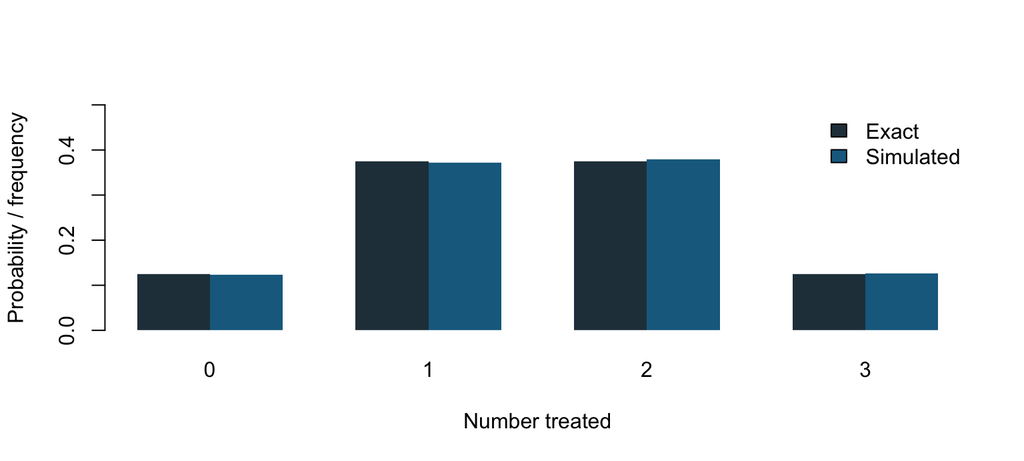

```r
barplot(rbind(pmf, freq(X)), beside = TRUE, names.arg = xs,
        col = c("#263d4a", "#176b8e"), border = NA,
        legend.text = c("Exact", "Simulated"),
        args.legend = list(x = "topright", bty = "n"),
        ylim = c(0, .5), xlab = "Number treated", ylab = "Probability / frequency")
```

**Try:** Change `N` to 100. Then restore 20,000. The theoretical PMF stays fixed. An unweighted sample of `0:3` would simulate a different distribution.

## 3. Mean, probability, and variance

**Before running:** Can the theoretical mean be the result of one experiment?

```r
set.seed(92303)
N <- 20000
xs <- 0:3
pmf <- c(1, 3, 3, 1) / 8
X <- sample(xs, N, replace = TRUE, prob = pmf)
mu <- sum(xs * pmf)
model_variance <- sum((xs - mu)^2 * pmf)
data.frame(quantity = c("Mean", "P(all same)", "Variance"),
           exact = c(mu, pmf[1] + pmf[4], model_variance),
           simulated = c(mean(X), mean(X == 0 | X == 3), mean((X - mu)^2)))
```

```
     quantity exact simulated
1        Mean  1.50   1.49175
2 P(all same)  0.25   0.24955
3    Variance  0.75   0.74910
```

```r
c(sample_variance = var(X), sample_sd = sd(X))
```

```
sample_variance       sample_sd
      0.7490694       0.8654879
```

`mean(X)` averages counts. `mean(X == 0 | X == 3)` averages a zero-one indicator. `var(X)` uses the sample mean and denominator `N-1`, so it can differ slightly from the displayed average squared deviation around the known model mean.

## 4. Repeated polls

**Before running:** Distinguish the number of polls from the number of voters within each poll. We assume known population support for this exercise.

```r
set.seed(92304)
N <- 20000
n_voters <- 300
p <- .46
polls <- rbinom(N, size = n_voters, prob = p)
cutoff <- n_voters / 2
data.frame(event = c("Strict lead", "Tie or lead"),
           exact = c(pbinom(floor(cutoff), n_voters, p, lower.tail = FALSE),
                     pbinom(ceiling(cutoff) - 1, n_voters, p, lower.tail = FALSE)),
           simulated = c(mean(polls > cutoff), mean(polls >= cutoff)))
```

```
        event      exact simulated
1 Strict lead 0.07398045   0.07165
2 Tie or lead 0.09154977   0.08990
```

```r
c(expected_count = n_voters * p, mean_count = mean(polls),
  expected_proportion = p, mean_proportion = mean(polls / n_voters),
  model_sd_proportion = sqrt(p * (1 - p) / n_voters))
```

```
     expected_count          mean_count expected_proportion     mean_proportion
       138.00000000        137.97330000          0.46000000          0.45991100
model_sd_proportion
         0.02877499
```

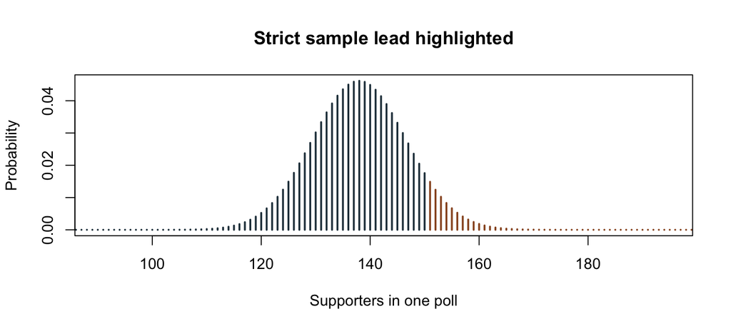

```r
counts <- 0:n_voters
plot(counts, dbinom(counts, n_voters, p), type = "h", lwd = 2,
     col = ifelse(counts > cutoff, "#985326", "#263d4a"),
     xlim = n_voters * c(.30, .65), xlab = "Supporters in one poll",
     ylab = "Probability", main = "Strict sample lead highlighted")
```

**Try:** Hold `n_voters` fixed and change `N`. Then hold `N` fixed and change `n_voters` to 1,200. Only the second changes the model SD of the proportion. Neither calculation estimates a posterior probability of election victory.

## 5. A discrete CDF and its jumps

**Before running:** Compare $P(X<1)$ and $P(X\le1)$.

```r
xs <- 0:3
pmf <- c(1, 3, 3, 1) / 8
data.frame(x = xs, pmf = pmf, cdf = cumsum(pmf))
```

```
  x   pmf   cdf
1 0 0.125 0.125
2 1 0.375 0.500
3 2 0.375 0.875
4 3 0.125 1.000
```

```r
c(less_than_1 = sum(pmf[xs < 1]), at_most_1 = sum(pmf[xs <= 1]))
```

```
less_than_1   at_most_1
      0.125       0.500
```

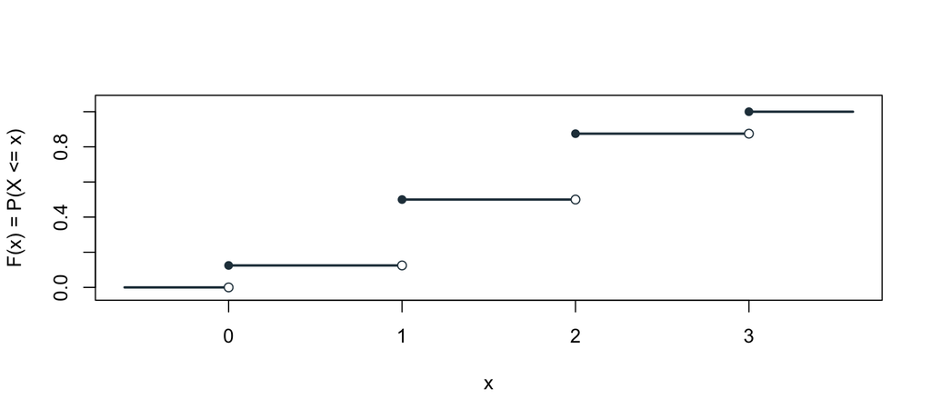

```r
cuts <- c(-.6, xs, 3.6)
heights <- c(0, cumsum(pmf))
plot(NA, xlim = c(-.6, 3.6), ylim = c(-.03, 1.05),
     xlab = "x", ylab = "F(x) = P(X <= x)")
segments(cuts[-length(cuts)], heights, cuts[-1], heights,
         lwd = 2, col = "#263d4a")
points(xs, cumsum(pmf), pch = 16, col = "#263d4a")
points(xs, c(0, cumsum(pmf)[1:3]), pch = 21, bg = "white", col = "#263d4a")
```

At 1, the jump is $3/8$. Between 1 and 2, the CDF remains $1/2$.

## 6. Transforming values and combining probabilities

**Before running:** Use the arrows in the slide diagram to predict the probabilities of $Y=(X-1.5)^2$.

```r
set.seed(92306)
N <- 20000
xs <- 0:3
pmf <- c(1, 3, 3, 1) / 8
X <- sample(xs, N, replace = TRUE, prob = pmf)
Y <- (X - 1.5)^2
data.frame(x = xs, y = (xs - 1.5)^2, probability = pmf)
```

```
  x    y probability
1 0 2.25       0.125
2 1 0.25       0.375
3 2 0.25       0.375
4 3 2.25       0.125
```

```r
aggregate(probability ~ y,
          data = data.frame(y = (xs - 1.5)^2, probability = pmf), FUN = sum)
```

```
     y probability
1 0.25        0.75
2 2.25        0.25
```

```r
table(factor(Y, levels = c(.25, 2.25))) / N
```

```
   0.25    2.25
0.75285 0.24715
```

```r
c(exact_mean_Y = sum((xs - 1.5)^2 * pmf), simulated_mean_Y = mean(Y),
  function_of_exact_mean = (sum(xs * pmf) - 1.5)^2)
```

```
          exact_mean_Y       simulated_mean_Y function_of_exact_mean
                0.7500                 0.7443                 0.0000
```

`aggregate()` combines masses with the same destination. Compare averaging after applying the function with applying it to the average.

## 7. Independent variables and copied values

**Before running:** Predict the variances of `X + Z` and `X + X`.

```r
set.seed(92307)
N <- 20000
X <- rbinom(N, 3, .5)
Z <- rbinom(N, 3, .5)
data.frame(quantity = c("Mean X+Z", "Mean X+X", "Variance X+Z", "Variance X+X"),
           exact = c(3, 3, 1.5, 3),
           simulated = c(mean(X + Z), mean(X + X), var(X + Z), var(X + X)))
```

```
      quantity exact simulated
1     Mean X+Z   3.0  2.989800
2     Mean X+X   3.0  3.002800
3 Variance X+Z   1.5  1.528072
4 Variance X+X   3.0  3.012143
```

Linearity of expectation applies to both sums. Variance additivity needs additional conditions, such as independence. A copied value is perfectly dependent on the original.

## 8. Waiting for the first volunteer

**Before running:** What should the counter return if the first call succeeds?

```r
set.seed(92308)
N <- 20000
p <- .2
G <- replicate(N, {
  failures <- 0L
  while (sample(c(FALSE, TRUE), 1, prob = c(1 - p, p)) == FALSE) {
    failures <- failures + 1L
  }
  failures
})
G_direct <- rgeom(N, prob = p)
data.frame(quantity = c("Failures", "Total calls", "P(more than five calls)"),
           exact = c((1 - p) / p, 1 / p, (1 - p)^5),
           loop = c(mean(G), mean(G + 1), mean(G >= 5)),
           direct = c(mean(G_direct), mean(G_direct + 1), mean(G_direct >= 5)))
```

```
                 quantity   exact   loop direct
1                Failures 4.00000 3.9525 3.9809
2             Total calls 5.00000 4.9525 4.9809
3 P(more than five calls) 0.32768 0.3220 0.3298
```

The first successful call stops the loop. `G` counts preceding failures. Keep `p` strictly above zero if you experiment with this loop. Do not truncate long episodes and silently treat them as complete.

## 9. Optional: other discrete models

The marble example revisits A2. The hotline example assumes a constant rate of two calls per hour and independent counts in disjoint intervals.

```r
set.seed(92309)
N <- 20000
reds <- rhyper(N, m = 5, n = 5, k = 6)
calls <- rpois(N, lambda = 2)
data.frame(event = c("Four red marbles", "At least three hotline calls"),
           exact = c(dhyper(4, 5, 5, 6), ppois(2, 2, lower.tail = FALSE)),
           simulated = c(mean(reds == 4), mean(calls >= 3)))
```

```
                         event     exact simulated
1             Four red marbles 0.2380952   0.24135
2 At least three hotline calls 0.3233236   0.32215
```

## Sources

Examples follow the accompanying lecture notes and [PSD Chapter 3](https://probstatsdata.com/discreterandomvariables.html). The hypothetical polling setup follows Example 3.21. The three-person assignment example adapts Matthew Blackwell’s course slides, used with permission.